# Probabilidades

Lista avaliativa 2 – Probabilidade e Estatística – 2023.1 – Respostas

fnaufel

(v. 25/06/2023)

# 1 Cães e gatos

A média de despesas veterinárias com um cachorro é $$500$, com desvio-padrão de $$150$.

A média de despesas veterinárias com um gato é $$600$, com desvio-padrão de $$175$.

1. Qual o valor esperado da diferença entre as despesas veterinárias com um cachorro e com um gato?
   - A variável aleatória $C$ representa as despesas com um cachorro.
   - $E(C) = 500$.
   - $V(C) = 150^2 = 22.500$.
   - A variável aleatória $G$ representa as despesas com um gato.
   - $E(G) = 600$.
   - $V(G) = 175^2 = 30.625$.
   - A diferença é a variável aleatória $D = G - C$.
   - O valor esperado da diferença é a diferença dos valores esperados:

     $$E(D) = E(G - C) = E(G) - E(C) = 600 - 500 = 100$$
2. Qual é o desvio-padrão dessa diferença?
   - A variância da diferença entre duas variáveis aleatórias é a soma das variâncias — lembre-se do [exemplo da caixa de cereal](https://youtu.be/8PI-rfsgNdE?t=1811):

     $$V(D) = V(G - C) = V(G) + V(C) = 22.500 + 30.625 = 53.125$$
   - Logo, o desvio-padrão da diferença é

     $$\sqrt{V(D)} = \sqrt{53125} \approx 230{,}49$$
3. Se as distribuições dos dois tipos de despesas forem normais, qual é a probabilidade de que as despesas veterinárias com um cachorro sejam maiores do que as despesas veterinárias com um gato?
   - A diferença entre duas variáveis com distribuições normais também tem uma distribuição normal.
   - Pelos itens anteriores, $D$ vai ter média $100$ e desvio-padrão $230{,}49$.
   - A probabilidade procurada é $P(D < 0)$ — lembrando que definimos $D = G - C$:

     ```r
     pnorm(0, 100, 230.49)
     ```

     ```
     ## [1] 0,3321957
     ```

# 2 Basquete

Um jogador costuma acertar $60\%$ dos seus lances livres.

Supondo que os lances livres são independentes entre si, qual é a probabilidade de que, no próximo jogo,

1. Ele erre pela primeira vez no quinto lance livre?

   Cada lance livre tem $0{,}6$ de probabilidade de ser um acerto.

   Como eles são independentes, para achar a probabilidade procurada, fazemos o produto das probabilidades de acertar ($4$ fatores) com a probabilidade de errar ($1$ fator):

   ```r
   p <- .6
   p^4 * (1 - p)
   ```

   ```
   ## [1] 0,05184
   ```

   Ou, usando a distribuição geométrica (com sucesso igual a errar e lembrando que a variável conta o número de fracassos antes do primeiro sucesso — $4$, neste caso):

   ```r
   dgeom(4, 1 - p)
   ```

   ```
   ## [1] 0,05184
   ```

2. Ele acerte pela primeira vez no quarto lance livre?

   Cada lance livre tem $0{,}6$ de probabilidade de ser um acerto.

   Como eles são independentes, para achar a probabilidade procurada, fazemos o produto das probabilidades de errar ($3$ fatores) com a probabilidade de acertar ($1$ fator):

   ```r
   p <- .6
   p * (1 - p)^3
   ```

   ```
   ## [1] 0,0384
   ```

   Ou, usando a distribuição geométrica (com sucesso igual a acertar e lembrando que a variável conta o número de fracassos antes do primeiro sucesso — $3$, neste caso):

   ```r
   dgeom(3, p)
   ```

   ```
   ## [1] 0,0384
   ```

3. Ele acerte pelo menos um dos primeiros $3$ lances livres?

   Cada lance livre tem $0{,}6$ de probabilidade de ser um acerto.

   A probabilidade procurada é $1 - P(\text{errar os }3\text{ primeiros lances})$.

   ```r
   p <- .6
   1 - (1 - p)^3
   ```

   ```
   ## [1] 0,936
   ```

   Ou, usando a distribuição binomial:

   ```r
   1 - dbinom(0, 3, p)
   ```

   ```
   ## [1] 0,936
   ```

   Ou:

   ```r
   pbinom(0, 3, p, lower.tail = FALSE)
   ```

   ```
   ## [1] 0,936
   ```

# 3 Bolas

Numa fábrica de bolas, um gerente registra a quantidade de bolas defeituosas na produção de cada dia.

Ele nota que

- A quantidade de bolas defeituosas por dia é pequena;
- A qualidade da produção de um dia não influencia a qualidade da produção do dia seguinte.

Responda:

1. Qual distribuição de probabilidade você deve usar para modelar o número de bolas defeituosas por dia? Por quê?

   Poisson. [Veja o vídeo.](https://youtu.be/F6OEoEaYrCw?t=906)
2. Se a média de bolas defeituosas por dia é $4{,}6$, qual a probabilidade de que nenhuma bola defeituosa seja produzida amanhã?

   ```r
   dpois(0, 4.6)
   ```

   ```
   ## [1] 0,01005184
   ```

3. Se a média de bolas defeituosas por dia é $4{,}6$, qual a probabilidade de que $6$ ou mais bolas defeituosas sejam produzidas amanhã?

   ```r
   ppois(6 - 1, 4.6, lower.tail = FALSE)
   ```

   ```
   ## [1] 0,3142405
   ```

# 4 Colesterol

Considere que o nível de colesterol na população de mulheres adultas é distribuído normalmente, com média de $196$mg/dL e desvio-padrão de $27$mg/dL.

1. Faça o gráfico desta distribuição.

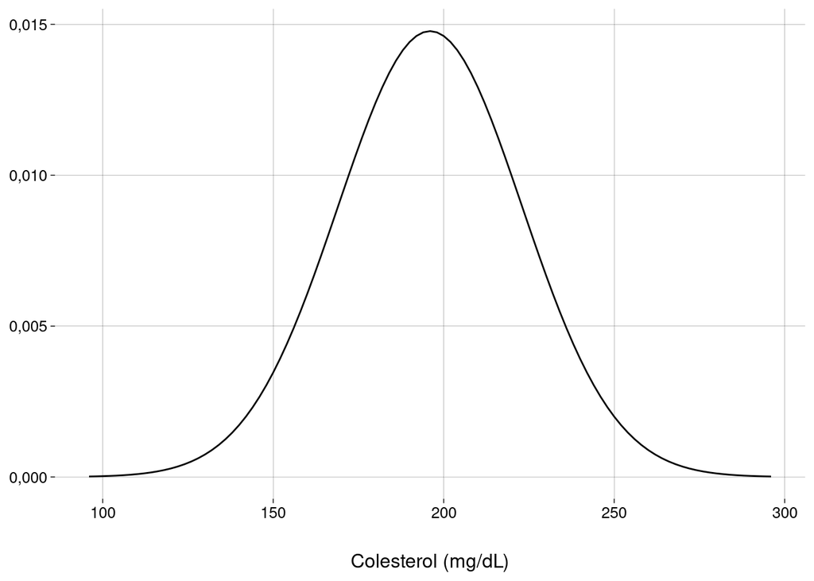

   ```r
   media <- 196
   dp <- 27
   minimo <- media - 96
   maximo <- media + 104

   breaks <- seq(minimo, maximo, 50)

   grafico <- ggplot() +
     stat_function(
       fun = dnorm,
       args = c(mean = media, sd = dp),
       xlim = c(media - 100, media + 100)
     ) +
     scale_x_continuous(breaks = breaks) +
     labs(
       y = NULL,
       x = 'Colesterol (mg/dL)'
     )

   grafico
   ```

2. Qual percentagem das mulheres tem níveis acima de $200$mg/dL?

   Basta ver quanto existe de probabilidade acumulada à direita de $200$:

   ```r
   pnorm(200, mean = media, sd = dp, lower.tail = FALSE)
   ```

   ```
   ## [1] 0,4411129
   ```

   Graficamente:

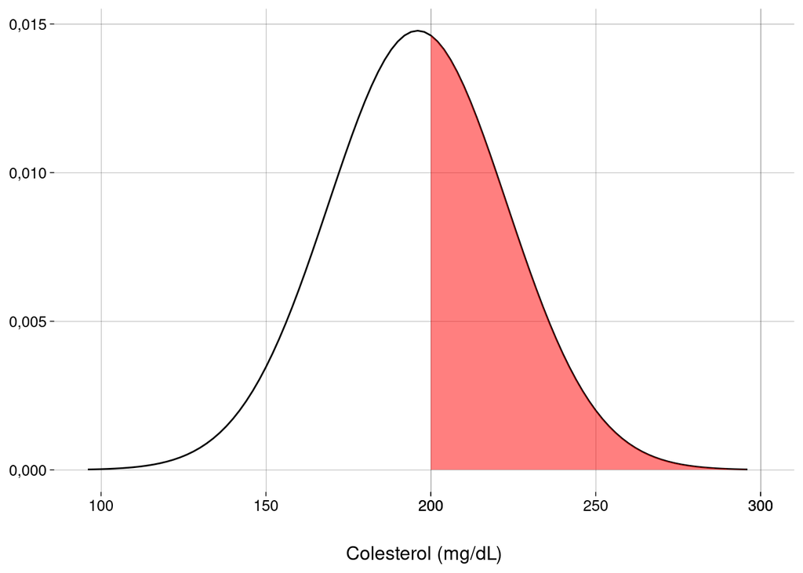

   ```r
   # Podemos guardar camadas de um ggplot em uma lista...
   faixa <- function(media, dp, esquerda, direita, breaks) {

     list(
       stat_function(
         fun = dnorm,
         args = c(mean = media, sd = dp),
         xlim = c(esquerda, direita),
         geom = 'area',
         fill = 'red',
         alpha = 0.5
       ),
       scale_x_continuous(
         breaks = c(breaks, esquerda, direita)
       )
     )

   }

   # ...para depois acrescentá-las a um gráfico.
   grafico + faixa(media, dp, 200, maximo, breaks)
   ```

3. Qual percentagem das mulheres tem níveis entre $170$mg/dL e $180$mg/dL?

   Basta ver quanto existe de probabilidade acumulada entre $170$ e $180$:

   ```r
   pnorm(180, mean = media, sd = dp) -
   pnorm(170, mean = media, sd = dp)
   ```

   ```
   ## [1] 0,1089439
   ```

   Graficamente:

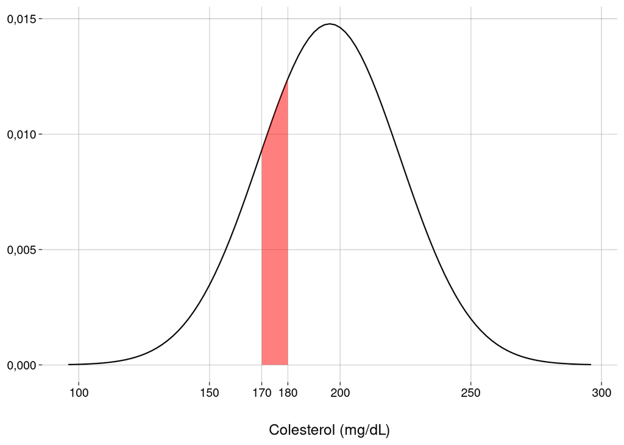

   ```r
   grafico + faixa(media, dp, 170, 180, breaks)
   ```

4. Qual o valor acima do qual estão os $15\%$ das mulheres com os níveis mais altos?

   Basta descobrir o quantil à direita do qual existem $15\%$ de probabilidade acumulada:

   ```r
   valor <- qnorm(.15, mean = media, sd = dp, lower.tail = FALSE)
   valor
   ```

   ```
   ## [1] 223,9837
   ```

   Graficamente:

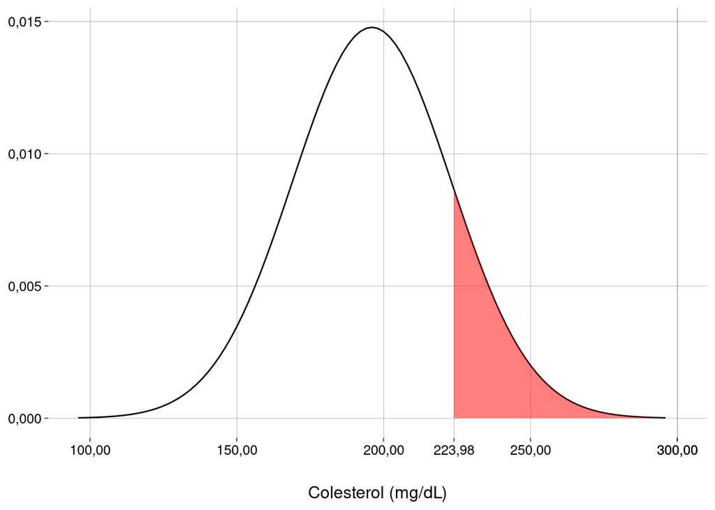

   ```r
     grafico + faixa(media, dp, valor %>% round(2), maximo, breaks)
   ```

Mostre seu raciocínio detalhado e use R para calcular as respostas.

# 5 Pessoas canhotas

Considere que $12\%$ da população é canhota.

De $100$ pessoas escolhidas independentemente, ao acaso, com probabilidade uniforme, qual é a probabilidade de

- Este problema trabalha com duas distribuições: a binomial e a geométrica.
- Vamos examinar quatro variáveis aleatórias e suas distribuições.
  - $X_d$ representa o número de pessoas destras dentre as $100$.

    A distribuição de $X_d$ vai ser a binomial.

    A probabilidade de sucesso é $p_d = 1 - 0{,}12 = 0{,}88$.

    Nossa amostra tem $100$ pessoas. Então, $n = 100$.

    O gráfico da distribuição de $X_d$ é

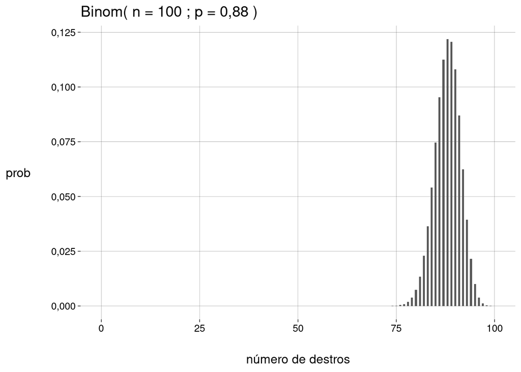

    ```r
    pdestro <- .88
    n <- 100
    tibble(x = 0:n, prob = dbinom(x, n, pdestro)) %>%
     ggplot(aes(x, prob)) +
       geom_col(width = .5) +
       labs(
         y = 'prob',
         x = 'número de destros',
         title = paste('Binom( n =', n, '; p =', pdestro, ')')
       )
    ```

  - $X_c$ representa o número de pessoas canhotas dentre as $100$.

    A distribuição de $X_c$ vai ser a binomial.

    A probabilidade de sucesso é $p_c = 0{,}12$.

    Nossa amostra tem $100$ pessoas. Então, $n = 100$.

    O gráfico da distribuição de $X_c$ é

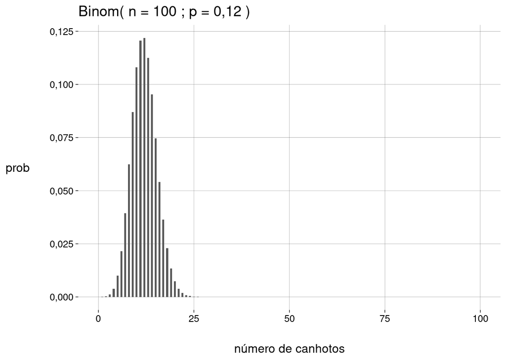

    ```r
    pcanhoto <- .12
    n <- 100
    tibble(x = 0:n, prob = dbinom(x, n, pcanhoto)) %>%
     ggplot(aes(x, prob)) +
       geom_col(width = .5) +
       labs(
         y = 'prob',
         x = 'número de canhotos',
         title = paste('Binom( n =', n, '; p =', pcanhoto, ')')
       )
    ```

  - $Y_d$ representa o número de pessoas destras (fracassos) encontradas antes de chegarmos à primeira pessoa canhota (sucesso).

    A distribuição de $Y_d$ vai ser a geométrica.

    A probabilidade de sucesso é $p_c = 0{,}12$.

    O gráfico da distribuição de $Y_d$ até um certo limite é

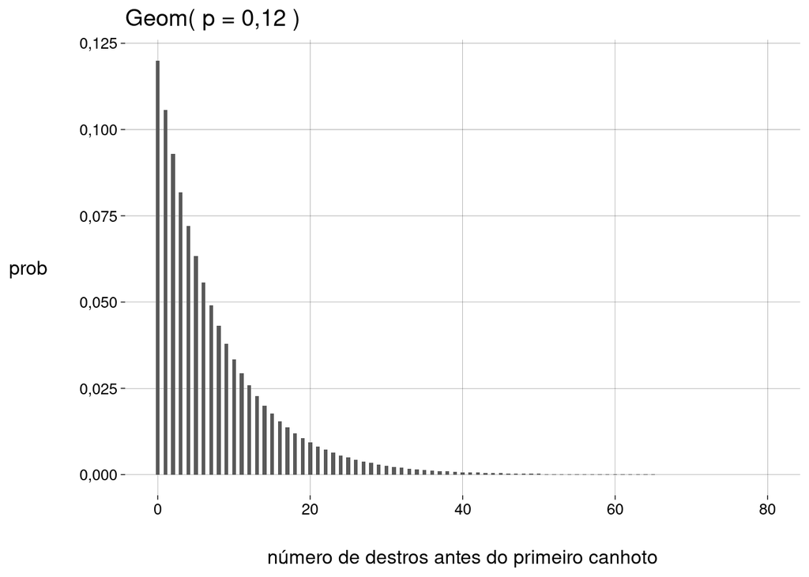

    ```r
    maximo <- 80
    tibble(x = 0:maximo, prob = dgeom(x, pcanhoto)) %>%
     ggplot(aes(x, prob)) +
       geom_col(width = .5) +
       labs(
         y = 'prob',
         x = 'número de destros antes do primeiro canhoto',
         title = paste('Geom( p =', pcanhoto, ')')
       )
    ```

  - $Y_c$ representa o número de pessoas canhotas (fracassos) encontradas antes de chegarmos à primeira pessoa destra (sucesso).

    A distribuição de $Y_c$ vai ser a geométrica.

    A probabilidade de sucesso é $p_d = 0{,}88$.

    O gráfico da distribuição de $Y_c$ até um certo limite é

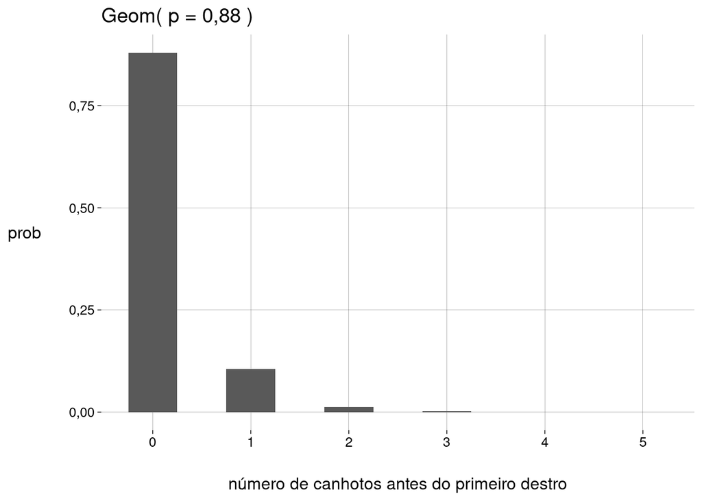

    ```r
    maximo <- 5
    tibble(x = 0:maximo, prob = dgeom(x, pdestro)) %>%
     ggplot(aes(x, prob)) +
       geom_col(width = .5) +
       labs(
         y = 'prob',
         x = 'número de canhotos antes do primeiro destro',
         title = paste('Geom( p =', pdestro, ')')
       ) +
       scale_x_continuous(breaks = 0:maximo)
    ```

1. A primeira pessoa canhota ser a $71$ª?

   As primeiras $70$ pessoas precisam ser destras, e a $71ª$ precisa ser canhota:

   ```r
   pdestro <- .88
   pcanhoto <- .12
   pdestro^70 * pcanhoto
   ```

   ```
   ## [1] 0,00001559439
   ```

   Usando a distribuição geométrica:

   ```r
   dgeom(70, pcanhoto)
   ```

   ```
   ## [1] 0,00001559439
   ```

2. Haver alguma pessoa canhota entre as primeiras $50$?

   É o complementar da probabilidade de as $50$ primeiras pessoas serem todas destras:

   ```r
   1 - pdestro^50
   ```

   ```
   ## [1] 0,9983245
   ```

   Ou, usando a distribuição binomial com $n = 50$:

   ```r
   1 - dbinom(0, 50, pcanhoto)
   ```

   ```
   ## [1] 0,9983245
   ```

   Uma pergunta:

   Esta probabilidade é igual à probabilidade de o primeiro canhoto aparecer entre as primeiras $50$ pessoas?

   Ou, o que significa o mesmo, a probabilidade $P(Y_d \leq 49)$, usando a variável aleatória $Y_d$ (que tem distribuição geométrica)?

   Vamos responder no geral:
   1. Defina $X \sim \text{Binom}(k, p)$.

      Vamos calcular a probabilidade de o primeiro sucesso aparecer entre as primeiras $k$ provas.

      Isto é igual à probabilidade de haver um número de fracassos menor ou igual a $k-1$ antes do primeiro sucesso:

      $$\begin{aligned}
      P(Y \leq k - 1)
      &= \sum_{i=0}^{k-1} p^i (1-p) \\
      &= (1-p) \sum_{i=0}^{k-1} p^i \\
      &= (1-p) \frac{1 - p^k}{1 - p} & \text{(soma de termos de P.G.)} \\
      &= 1 - p^k & \text{(supondo }p < 1\text{)}
      \end{aligned}$$

   De fato, as duas probabilidades são iguais.

   Então, usando a distribuição geométrica:

   ```r
   pgeom(49, pcanhoto)
   ```

   ```
   ## [1] 0,9983245
   ```

3. Haver exatamente $12$ pessoas canhotas no grupo?

   Usando a binomial:

   ```r
   dbinom(12, n, pcanhoto)
   ```

   ```
   ## [1] 0,1219028
   ```

4. Haver pelo menos $20$ pessoas canhotas no grupo?

   Usando a binomial, computando a probabilidade acumulada à direita de $19$ (exclusive):

   ```r
   pbinom(19, n, pcanhoto, lower.tail = FALSE)
   ```

   ```
   ## [1] 0,0147063
   ```

5. Não haver mais que $20$ pessoas canhotas no grupo?

   Usando a binomial, computando a probabilidade acumulada à esquerda de $20$ (inclusive):

   ```r
   pbinom(20, n, pcanhoto)
   ```

   ```
   ## [1] 0,9927306
   ```

Mostre seu raciocínio detalhado e use R para calcular as respostas.

# 6 Mega-sena (questão bônus, valendo 1 ponto)

Visite https://loterias.caixa.gov.br/Paginas/Mega-Sena.aspx e desça até a seção “Probabilidade”. Você verá a tabela

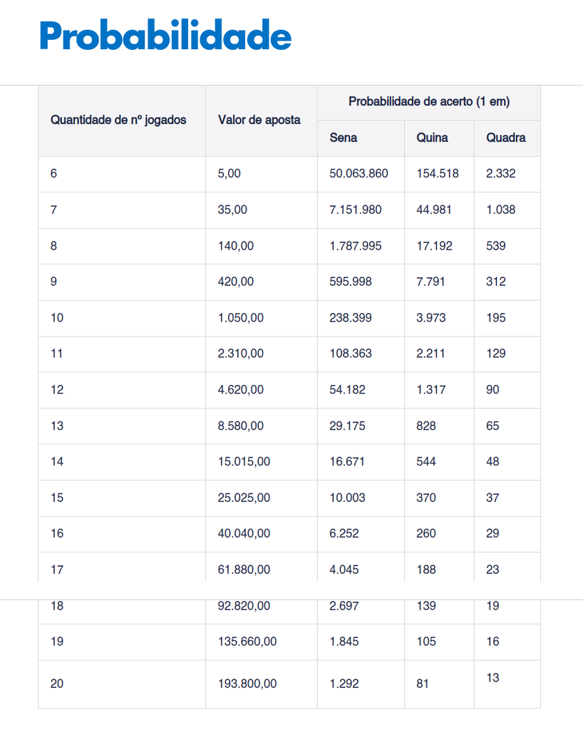

1. Explique em detalhes como a distribuição hipergeométrica é usada para calcular as probabilidades de acertar na sena.

   Leia sobre a [distribuição hipergeométrica](https://pt.wikipedia.org/wiki/Distribui%C3%A7%C3%A3o_hipergeom%C3%A9trica).

   A fórmula geral para
   - $a$ acertos
   - $j$ números jogados
   - $s$ números sorteados dentre
   - $t$ números no total

   é

   $$P(a \mid j, s, t) = \frac{{j \choose a}{t - j \choose s - a}}{t \choose s}$$

   O total de resultados possíveis é $t \choose s$, a quantidade de maneiras de sortear $s$ números dentre um total de $t$.

   A idéia é que, fixados os $j$ números jogados, para determinar a quantidade de resultados que têm exatamente $a$ acertos, é preciso
   - determinar quais são os $a$ acertos dentre os $j$ jogados: $j \choose a$, a quantidade de maneiras de acertar $a$ números dentre os $j$ jogados.
   - determinar os $s - a$ números sorteados restantes dentre os $t - j$ que não foram jogados: $t - j \choose s - a$
2. Escreva código em R para reproduzir a tabela de probabilidades de acerto na sena.

   ```r
   jogados <- 6:20

   sena <- dhyper(
     x = 6,
     m = jogados,
     n = 60 - jogados,
     k = 6) %>% round(10)

   quina <- dhyper(
     x = 5,
     m = jogados,
     n = 60 - jogados,
     k = 6) %>% round(10)

   quadra <- dhyper(
     x = 4,
     m = jogados,
     n = 60 - jogados,
     k = 6) %>% round(10)

   probs <- tibble(jogados, sena, quina, quadra)

   sena <- (
     1/dhyper(x = 6, m = jogados, n = 60 - jogados, k = 6)
   ) %>% round(0)

   quina <- (
     1/dhyper(x = 5, m = jogados, n = 60 - jogados, k = 6)
   ) %>% round(0)

   quadra <- (
     1/dhyper(x = 4, m = jogados, n = 60 - jogados, k = 6)
   ) %>% round(0)

   chances <- tibble(jogados, sena, quina, quadra)
   ```

   As chances de acertar são de $1$ em…

   ```r
   chances %>%
     kbl(format.args = list(big.mark = '.')) %>%
     kable_paper(
       c('striped', 'hover'),
       full_width = FALSE
     )
   ```

   | jogados | sena | quina | quadra |
   | --- | --- | --- | --- |
   | 6 | 50.063.860 | 154.518 | 2.332 |
   | 7 | 7.151.980 | 44.981 | 1.038 |
   | 8 | 1.787.995 | 17.192 | 539 |
   | 9 | 595.998 | 7.791 | 312 |
   | 10 | 238.399 | 3.973 | 195 |
   | 11 | 108.363 | 2.211 | 129 |
   | 12 | 54.182 | 1.317 | 90 |
   | 13 | 29.175 | 828 | 65 |
   | 14 | 16.671 | 544 | 48 |
   | 15 | 10.003 | 370 | 37 |
   | 16 | 6.252 | 260 | 29 |
   | 17 | 4.045 | 188 | 23 |
   | 18 | 2.697 | 139 | 19 |
   | 19 | 1.845 | 105 | 16 |
   | 20 | 1.292 | 81 | 13 |

   Dito de outro modo, as probabilidades de acertar são

   ```r
   probs %>%
     kbl(digits = 9, format.args = list(big.mark = '.')) %>%
     kable_paper(
       c('striped', 'hover'),
       full_width = FALSE
     )
   ```

   | jogados | sena | quina | quadra |
   | --- | --- | --- | --- |
   | 6 | 0,000000020 | 0,000006472 | 0,000428752 |
   | 7 | 0,000000140 | 0,000022232 | 0,000963370 |
   | 8 | 0,000000559 | 0,000058166 | 0,001854032 |
   | 9 | 0,000001678 | 0,000128356 | 0,003208902 |
   | 10 | 0,000004195 | 0,000251679 | 0,005138437 |
   | 11 | 0,000009228 | 0,000452182 | 0,007751699 |
   | 12 | 0,000018456 | 0,000759350 | 0,011152955 |
   | 13 | 0,000034276 | 0,001208237 | 0,015438582 |
   | 14 | 0,000059983 | 0,001839491 | 0,020694269 |
   | 15 | 0,000099972 | 0,002699252 | 0,026992525 |
   | 16 | 0,000159956 | 0,003838937 | 0,034390476 |
   | 17 | 0,000247204 | 0,005314892 | 0,042927972 |
   | 18 | 0,000370806 | 0,007187940 | 0,052625986 |
   | 19 | 0,000541948 | 0,009522797 | 0,063485317 |
   | 20 | 0,000774211 | 0,012387379 | 0,075485590 |

   Para fins de comparação:
   - A probabilidade de você lançar uma moeda não-viciada $26$ vezes e obter cara em *todos* os lançamentos é de $0{,}000000015$.
   - A probabilidade de você lançar $10$ dados não-viciados e conseguir $6$ em *todos* eles é de $0{,}000000017$.
3. Explique por que os preços das apostas são justos.

   Mais especificamente, um jogo de $7$ números tem a mesma probabilidade de acertar a sena que $7$ jogos de $6$ números.

   Por isso, o valor do jogo de $7$ números é $7$ vezes o valor de um jogo de $6$ números.
   1. Explique por que um jogo de $7$ números tem a mesma probabilidade de acertar a sena que $7$ jogos de $6$ números.

      Um jogo de $7$ números cobre $\binom76 = 7$ senas diferentes; logo, equivale a $7$ jogos de $6$ números.

      Um jogo de $8$ números cobre $\binom86 = 28$ senas diferentes; logo, equivale a $28$ jogos de $6$ números.

      E assim por diante.
   2. Para $n \in \{8, 9, 10, \ldots, 20 \}$, escreva código em R para responder à pergunta

      Um jogo de $n$ números equivale a quantos jogos de $6$ números?

      ```r
      tibble(
        n = 8:20,
        senas = choose(n, 6)
      ) %>%
      kbl(digits = 9, format.args = list(big.mark = '.')) %>%
      kable_paper(
        c('striped', 'hover'),
        full_width = FALSE
      )
      ```

      | n | senas |
      | --- | --- |
      | 8 | 28 |
      | 9 | 84 |
      | 10 | 210 |
      | 11 | 462 |
      | 12 | 924 |
      | 13 | 1.716 |
      | 14 | 3.003 |
      | 15 | 5.005 |
      | 16 | 8.008 |
      | 17 | 12.376 |
      | 18 | 18.564 |
      | 19 | 27.132 |
      | 20 | 38.760 |